# Pertemuan 5

Natasha Muti Hafiza

2023-09-26

```r
library(ggplot2)
library(tsibble)
library(tseries)
library(MASS)
```

```r
dataa <- rio::import("https://raw.githubusercontent.com/natashamuti/mpdw-ako/main/pertemuan%201/data.csv")
str(dataa)
```

```
## 'data.frame':    249 obs. of  2 variables:
##  $ Date: chr  "30/01/2021" "29/01/2021" "28/01/2021" "27/01/2021" ...
##  $ High: num  34933 38532 33784 32557 32922 ...
```

```r
data <- dataa$High
data
```

```
##   [1] 34933.00 38531.90 33783.98 32557.29 32921.88 34875.00 33071.00 33456.00
##   [9] 33826.53 35600.00 36415.31 37850.00 37469.83 36852.50 37950.00 39747.76
##  [17] 40100.00 37850.00 36628.00 38264.74 41350.00 41380.00 41950.00 40365.00
##  [25] 36939.21 34360.00 33600.00 34778.11 33300.00 29600.00 29300.00 28996.00
##  [33] 27410.00 27500.00 28422.00 26867.03 24789.86 23794.43 24100.00 23837.10
##  [41] 24102.77 24295.00 24171.47 23285.18 23800.00 21560.00 19570.00 19349.00
##  [49] 19411.00 18948.66 18292.73 18557.32 18639.57 19294.84 19420.91 19420.00
##  [57] 19177.00 19527.00 19598.00 19342.00 19888.00 19863.16 18360.05 17880.49
##  [65] 17457.62 18915.03 19484.21 19418.97 18766.00 18750.00 18965.90 18815.22
##  [73] 18179.80 18476.93 17858.82 16880.00 16180.00 16326.99 16480.00 16340.70
##  [81] 15965.00 15460.00 15840.00 15650.00 15753.52 15960.00 15750.00 14259.00
##  [89] 14066.11 13830.00 13895.00 14100.00 13669.98 13642.91 13859.48 13789.29
##  [97] 13238.81 13350.00 13166.73 13027.69 13185.00 13217.68 12038.38 11823.99
## [105] 11505.00 11402.42 11541.15 11617.34 11547.98 11557.00 11720.01 11445.00
## [113] 11491.00 11104.64 10950.00 10681.87 10800.00 10798.00 10696.87 10603.56
```

[output cut: 17 more lines]

```r
data.ts<-ts(data)
data.ts
```

```
## Time Series:
## Start = 1
## End = 249
## Frequency = 1
##   [1] 34933.00 38531.90 33783.98 32557.29 32921.88 34875.00 33071.00 33456.00
##   [9] 33826.53 35600.00 36415.31 37850.00 37469.83 36852.50 37950.00 39747.76
##  [17] 40100.00 37850.00 36628.00 38264.74 41350.00 41380.00 41950.00 40365.00
##  [25] 36939.21 34360.00 33600.00 34778.11 33300.00 29600.00 29300.00 28996.00
##  [33] 27410.00 27500.00 28422.00 26867.03 24789.86 23794.43 24100.00 23837.10
##  [41] 24102.77 24295.00 24171.47 23285.18 23800.00 21560.00 19570.00 19349.00
##  [49] 19411.00 18948.66 18292.73 18557.32 18639.57 19294.84 19420.91 19420.00
##  [57] 19177.00 19527.00 19598.00 19342.00 19888.00 19863.16 18360.05 17880.49
##  [65] 17457.62 18915.03 19484.21 19418.97 18766.00 18750.00 18965.90 18815.22
##  [73] 18179.80 18476.93 17858.82 16880.00 16180.00 16326.99 16480.00 16340.70
##  [81] 15965.00 15460.00 15840.00 15650.00 15753.52 15960.00 15750.00 14259.00
```

[output cut: 21 more lines]

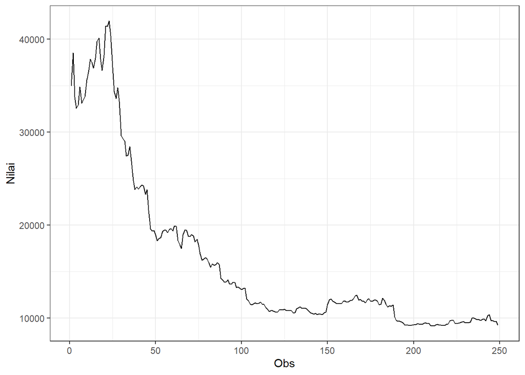

```r
plot_data.ts <- data.ts |> as_tsibble() |>
  ggplot(aes(x = index, y = value)) + geom_line() + theme_bw() +
  xlab("Obs") + ylab("Nilai")
plot_data.ts
```

```r
mean(data.ts)
```

```
## [1] 16051.51
```

Plot deret waktu di atas menunjukkan bahwa data tidak stasioner dalam rataan, ditandai dengan data yang memiliki tren dan tidak stasioner dalam ragam, ditandai dengan lebar pita yang tidak sama.

### Plot ACF

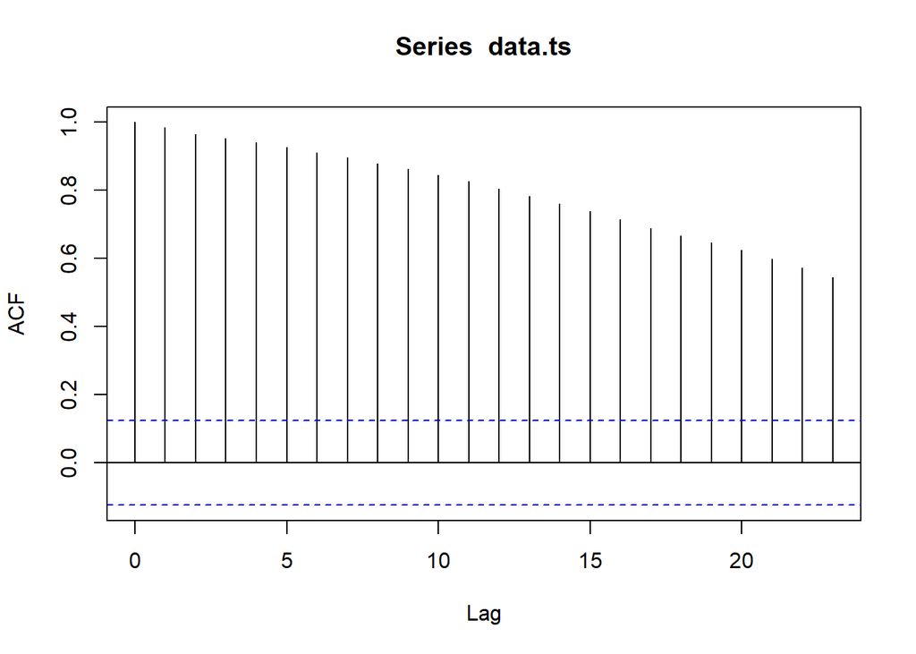

```r
acf(data.ts)
```

Berdasarkan plot ACF, terlihat bahwa plot ACF pada data tersebut menurun secara perlahan (*tails off slowly*) yang menandakan data tidak stasioner dalam rataan

### Uji ADF

```r
tseries::adf.test(data.ts)
```

```
##
##  Augmented Dickey-Fuller Test
##
## data:  data.ts
## Dickey-Fuller = -1.6215, Lag order = 6, p-value = 0.7351
## alternative hypothesis: stationary
```

$H_0$ : Data tidak stasioner dalam rataan

$H_1$ : Data stasioner dalam rataan

Berdasarkan uji ADF tersebut, didapat *p-value* sebesar 0.735 yang lebih besar dari taraf nyata 5% sehingga terima $H_0$ dan menandakan bahwa data tidak stasioner dalam rataan. Hal ini sesuai dengan hasil eksplorasi menggunakan plot time series dan plot ACF.

### Plot Box-Cox

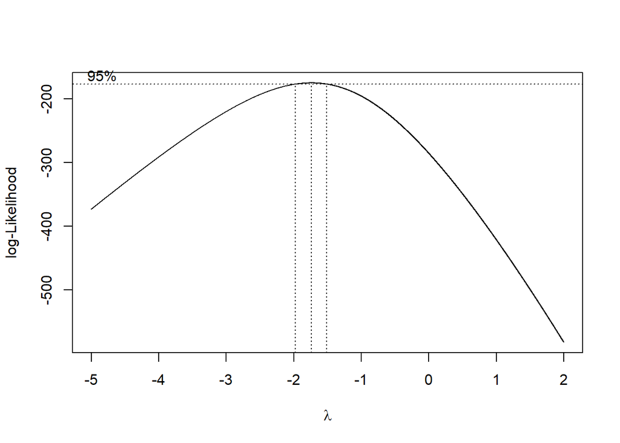

```r
index <- seq(1:249)
bc = boxcox(data.ts~index, lambda = seq(-5,2,by=0.001))
```

```r
#Nilai Rounded Lambda
lambda <- bc$x[which.max(bc$y)]
lambda
```

```
## [1] -1.741
```

```r
#SK
bc$x[bc$y > max(bc$y) - 1/2 * qchisq(.95,1)]
```

```
##   [1] -1.977 -1.976 -1.975 -1.974 -1.973 -1.972 -1.971 -1.970 -1.969 -1.968
##  [11] -1.967 -1.966 -1.965 -1.964 -1.963 -1.962 -1.961 -1.960 -1.959 -1.958
##  [21] -1.957 -1.956 -1.955 -1.954 -1.953 -1.952 -1.951 -1.950 -1.949 -1.948
##  [31] -1.947 -1.946 -1.945 -1.944 -1.943 -1.942 -1.941 -1.940 -1.939 -1.938
##  [41] -1.937 -1.936 -1.935 -1.934 -1.933 -1.932 -1.931 -1.930 -1.929 -1.928
##  [51] -1.927 -1.926 -1.925 -1.924 -1.923 -1.922 -1.921 -1.920 -1.919 -1.918
##  [61] -1.917 -1.916 -1.915 -1.914 -1.913 -1.912 -1.911 -1.910 -1.909 -1.908
##  [71] -1.907 -1.906 -1.905 -1.904 -1.903 -1.902 -1.901 -1.900 -1.899 -1.898
##  [81] -1.897 -1.896 -1.895 -1.894 -1.893 -1.892 -1.891 -1.890 -1.889 -1.888
##  [91] -1.887 -1.886 -1.885 -1.884 -1.883 -1.882 -1.881 -1.880 -1.879 -1.878
## [101] -1.877 -1.876 -1.875 -1.874 -1.873 -1.872 -1.871 -1.870 -1.869 -1.868
## [111] -1.867 -1.866 -1.865 -1.864 -1.863 -1.862 -1.861 -1.860 -1.859 -1.858
## [121] -1.857 -1.856 -1.855 -1.854 -1.853 -1.852 -1.851 -1.850 -1.849 -1.848
## [131] -1.847 -1.846 -1.845 -1.844 -1.843 -1.842 -1.841 -1.840 -1.839 -1.838
## [141] -1.837 -1.836 -1.835 -1.834 -1.833 -1.832 -1.831 -1.830 -1.829 -1.828
```

[output cut: 32 more lines]

Gambar di atas menunjukkan nilai *rounded value* ($\lambda$) optimum sebesar **-1.741** dan pada selang kepercayaan 95% nilai memiliki batas bawah **-1.977** dan batas atas **-1.513**. Selang tersebut tidak memuat nilai satu sehingga dapat dikatakan bahwa data tidak stasioner dalam ragam.

### Partisi Data

#### Bagian 1

```r
dtbag1 <- data.ts[67:106] |> ts()
mean(dtbag1)
```

```
## [1] 15309.24
```

```r
var(dtbag1)
```

```
## [1] 5499271
```

#### Plot Time Series

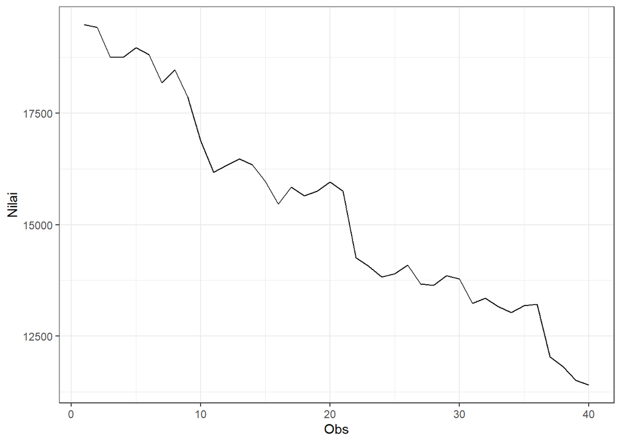

```r
dtbag1 |> as_tsibble() |>
  ggplot(aes(x = index, y = value)) +
  geom_line() + theme_bw() +
  xlab("Obs") + ylab("Nilai")
```

Berdasarkan plot time series tersebut, terlihat bahwa data tidak stasioner dalam rataan karena masih terdapat tren pada data, dan tidak stasioner dalam ragam karena memiliki lebar pita yang berbeda

#### Plot ACF

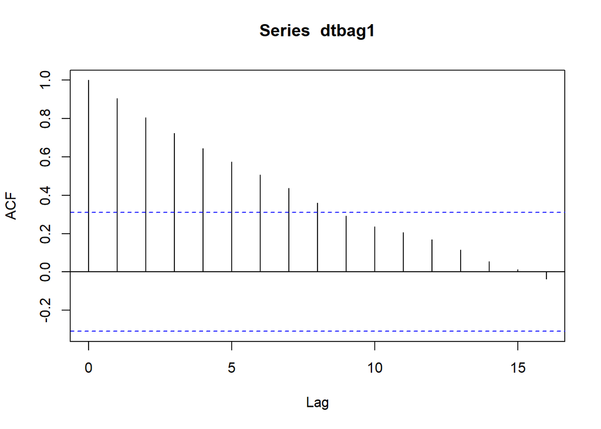

```r
acf(dtbag1)
```

Berdasarkan plot ACF, terlihat bahwa plot ACF pada data tersebut menurun secara perlahan (*tails off slowly*) yang menandakan data tidak stasioner dalam rataan

#### Uji ADF

```r
adf.test(dtbag1)
```

```
##
##  Augmented Dickey-Fuller Test
##
## data:  dtbag1
## Dickey-Fuller = -2.4561, Lag order = 3, p-value = 0.3945
## alternative hypothesis: stationary
```

$H_0$ : Data tidak stasioner dalam rataan

$H_1$ : Data stasioner dalam rataan

Berdasarkan uji ADF tersebut, didapat *p-value* sebesar 0.3945 yang lebih besar dari taraf nyata 5% dan menandakan bahwa data tidak stasioner dalam rataan. Hal ini sesuai dengan hasil eksplorasi menggunakan plot time series dan plot ACF

#### Bagian 2

```r
dtbag2 <- data.ts[106:150] |> ts()
mean(dtbag2)
```

```
## [1] 10905.18
```

```r
var(dtbag2)
```

```
## [1] 146222.9
```

#### Plot Time Series

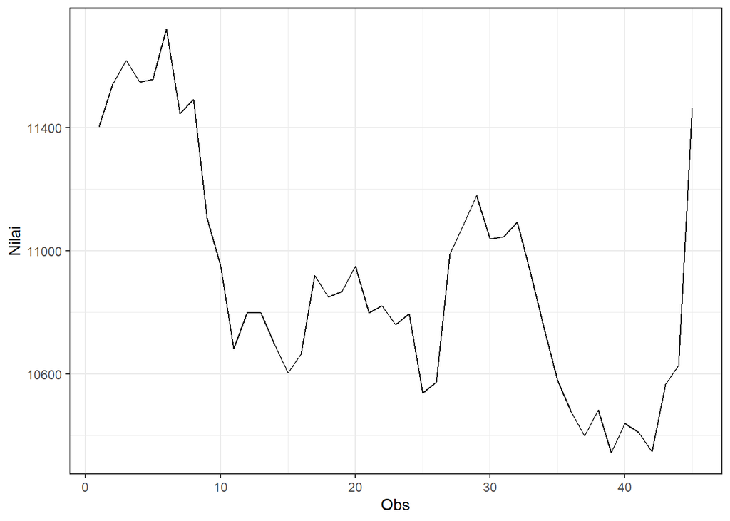

```r
dtbag2 |> as_tsibble() |>
  ggplot(aes(x = index, y = value)) +
  geom_line() + theme_bw() +
  xlab("Obs") + ylab("Nilai")
```

Berdasarkan plot time series tersebut, terlihat bahwa data tidak stasioner dalam rataan karena masih terdapat tren pada data, dan tidak stasioner dalam ragam karena memiliki lebar pita yang cenderung tidak sama

#### Plot ACF

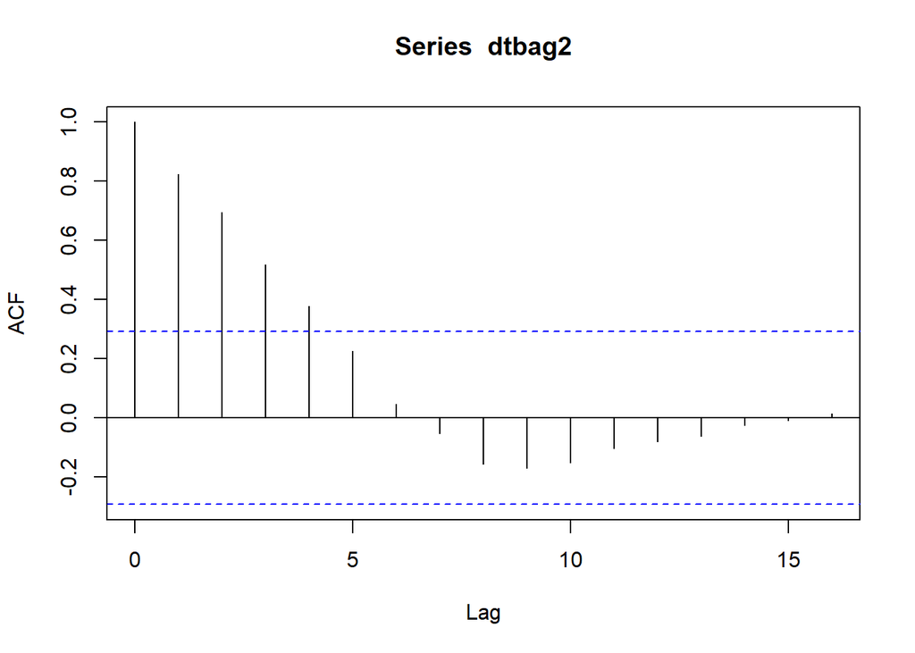

```r
acf(dtbag2)
```

#### Uji ADF

```r
adf.test(dtbag2)
```

```
##
##  Augmented Dickey-Fuller Test
##
## data:  dtbag2
## Dickey-Fuller = -1.7352, Lag order = 3, p-value = 0.6789
## alternative hypothesis: stationary
```

$H_0$ : Data tidak stasioner dalam rataan

$H_1$ : Data stasioner dalam rataan